# Latihan Praktikum 1 MPDW

## Library/Packages

```r
#install.packages("forecast")
#install.packages("graphics")
#install.packages("TTR")
#install.packages("TSA")
#install.packages("rio")
```

```r
library(forecast)
library(graphics)
library(TTR)
library(TSA)
library(rio)
```

# Impor Data

```r
data <- import("https://raw.githubusercontent.com/naylatiara/MPDW/refs/heads/main/pertemuan%201/india_2000_2024_daily_weather%20-%20Sheet1%20(2).csv")

head(data)
```

```
##    KOTA    TANGGAL SUHU_MAX
## 1 Delhi 20/10/2023    29.02
## 2 Delhi 21/10/2023    29.07
## 3 Delhi 22/10/2023    30.03
## 4 Delhi 23/10/2023    29.09
## 5 Delhi 24/10/2023    30.07
## 6 Delhi 25/10/2023    30.09
```

```r
data$TANGGAL <- as.Date(data$TANGGAL, format = "%d/%m/%Y")
data$SUHU_MAX <- as.numeric(data$SUHU_MAX)
```

# Eksplorasi Data

```r
View(data)
str(data)
```

```
## 'data.frame':    146 obs. of  3 variables:
##  $ KOTA    : chr  "Delhi" "Delhi" "Delhi" "Delhi" ...
##  $ TANGGAL : Date, format: "2023-10-20" "2023-10-21" ...
##  $ SUHU_MAX: num  29 29.1 30 29.1 30.1 ...
```

```r
dim(data)
```

```
## [1] 146   3
```

### Mengubah data agar terbaca sebagai deret waktu

```r
data.ts <- (data$SUHU_MAX)
data.ts
```

```
##   [1] 29.02 29.07 30.03 29.09 30.07 30.09 30.07 30.04 30.00 31.03 31.07 30.09
##  [13] 30.04 30.04 28.05 29.06 29.05 29.04 29.09 29.05 29.02 26.01 25.01 25.01
##  [25] 25.03 25.01 25.06 26.00 26.07 26.01 25.05 25.04 25.03 24.09 24.06 25.00
##  [37] 25.00 25.05 24.02 20.04 24.04 21.02 24.00 24.01 24.03 22.08 23.02 23.05
##  [49] 24.01 23.08 23.04 22.06 21.09 22.08 22.07 22.01 21.08 22.03 22.05 21.06
##  [61] 21.06 20.05 21.05 21.02 22.00 22.07 22.09 22.03 21.05 20.07 19.08 18.04
##  [73] 18.04 16.01 15.00 15.04 17.05 17.01 16.09 17.04 18.04 18.00 15.09 15.03
##  [85] 17.04 17.08 17.07 15.08 17.00 17.08 17.04 16.04 15.08 16.00 16.05 17.02
##  [97] 18.01 17.02 18.03 20.04 20.01 21.02 20.03 19.09 21.00 19.02 20.04 21.01
## [109] 19.07 18.06 18.03 19.00 20.04 19.07 21.04 21.05 21.00 22.06 23.07 24.04
## [121] 24.06 27.05 27.02 27.04 26.01 24.02 23.00 23.01 25.00 24.05 24.03 24.03
## [133] 26.04 26.06 25.02 22.02 21.02 20.05 21.00 23.08 25.01 25.01 26.03 29.03
## [145] 29.02 29.02
```

```r
#Menampilkan ringkasan data
summary(data.ts)
```

```
##    Min. 1st Qu.  Median    Mean 3rd Qu.    Max.
##   15.00   20.02   22.09   22.70   25.05   31.07
```

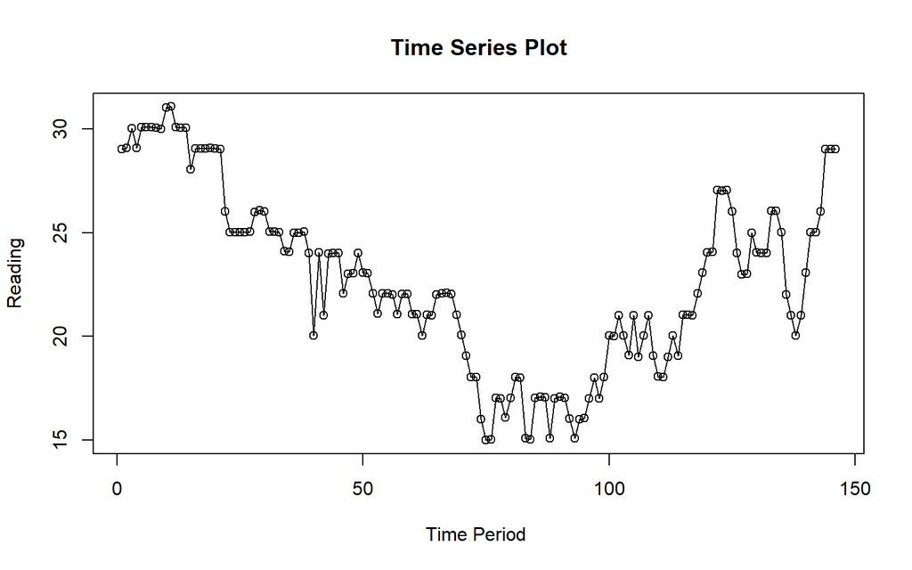

```r
#Membuat plot data deret waktu
ts.plot(data.ts, xlab="Time Period ", ylab="Reading",
        main = "Time Series Plot")
points(data.ts)
```

# Single Moving Average & Double Moving Average

## Pembagian Data

Pembagian data latih dan data uji dilakukan dengan perbandingan 80% data latih dan 20% data uji

```r
#hitung jumlah daya
n <- nrow(data)

#tentukan natas 80%
n_train <- floor(0.8 * n)

#bagi data
training <- data[1:n_train, ]
testing <- data[(n_train+1):n, ]

#ubah ke time series
train.ts <- ts(training$SUHU_MAX)
test.ts <- ts(testing$SUHU_MAX)
```

Eksplorasi data dilakukan pada keseluruhan data, data latih serta data uji menggunakan plot data deret waktu.

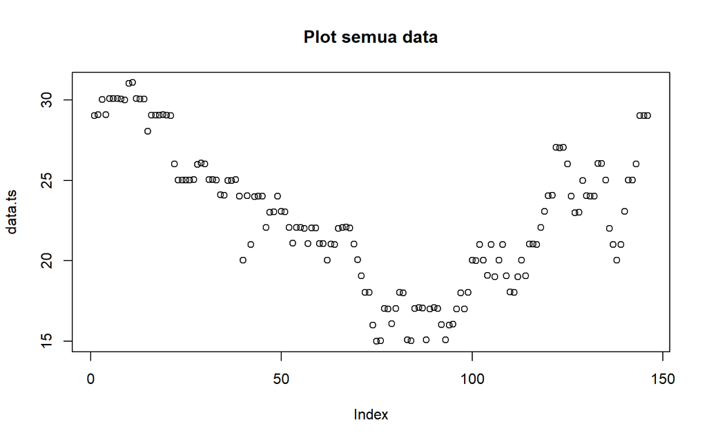

```r
#Eksplorasi Keseluruhan data
plot(data.ts, col="red", main="Plot semua data")
points(data.ts)
```

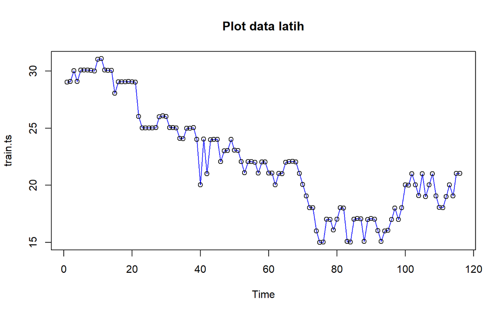

```r
#Ekspllorasi data latih
plot(train.ts, col="blue", main="Plot data latih")
points(train.ts)
```

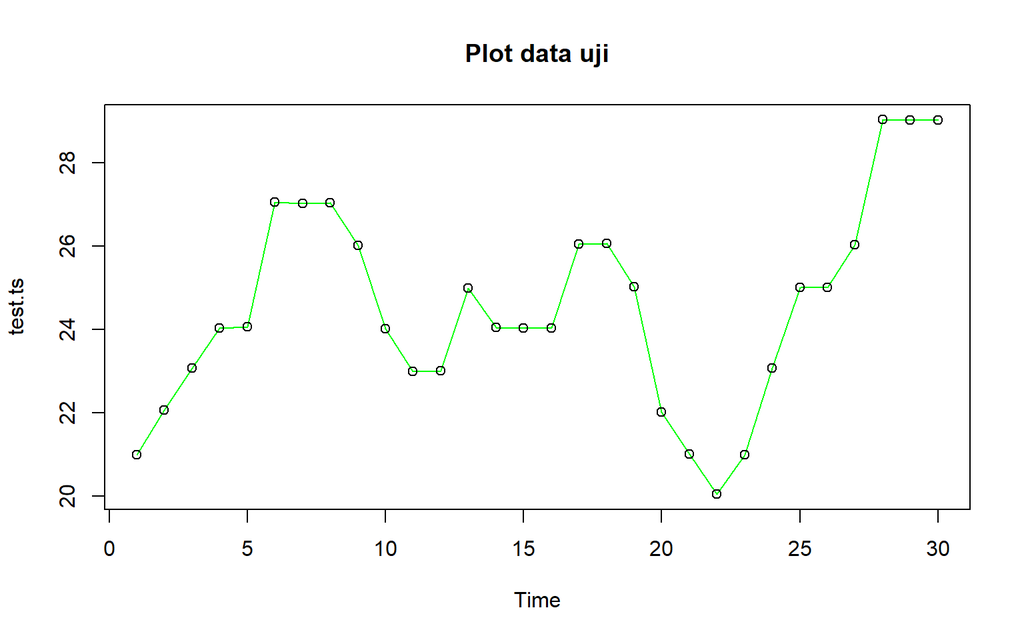

```r
#Eksplorasi data uji
plot(test.ts, col="green", main="Plot data uji")
points(test.ts)
```

Eksplorasi data juga dapat dilakukan menggunakan package `ggplot2` dengan terlebih dahulu memanggil library *package* `ggplot2`

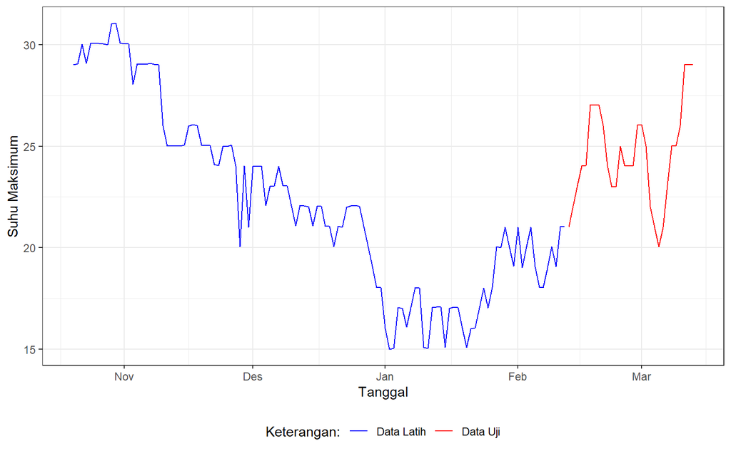

```r
library(ggplot2)
ggplot() +
  geom_line(data = training, aes(x = TANGGAL, y = SUHU_MAX, col = "Data Latih")) +
  geom_line(data = testing, aes(x = TANGGAL, y = SUHU_MAX, col = "Data Uji")) +
  labs(x = "Tanggal", y = "Suhu Maksimum", color = "Legend") +
   scale_colour_manual(name="Keterangan:", breaks = c("Data Latih", "Data Uji"),
                      values = c("blue", "red")) +
  theme_bw() + theme(legend.position = "bottom",
                     plot.caption = element_text(hjust=0.5, size=12))
```

#Single Moving Average (SMA) Pemulusan menggunakan metode SMA dilakukan dengan fungsi `SMA()`. Dalam hal ini akan dilakukan pemulusan dengan parameter `m=4`

```r
data.sma <- SMA(train.ts, n=4)
data.sma
```

```
## Time Series:
## Start = 1
## End = 116
## Frequency = 1
##   [1]      NA      NA      NA 29.3025 29.5650 29.8200 29.8300 30.0675 30.0500
##  [10] 30.2850 30.5350 30.5475 30.5575 30.3100 29.5550 29.2975 29.0500 28.8000
##  [19] 29.0600 29.0575 29.0500 28.2925 27.2725 26.2625 25.2650 25.0150 25.0275
##  [28] 25.2750 25.5350 25.7850 25.7825 25.5425 25.2825 24.8025 24.5550 24.5450
##  [37] 24.5375 24.7775 24.7675 23.5275 23.2875 22.2800 22.2750 23.2675 23.2650
##  [46] 23.5300 23.2850 23.0450 23.0400 23.2900 23.2950 23.0475 22.3175 22.0675
##  [55] 21.8250 21.8125 21.8100 21.7975 21.7925 21.5550 21.5500 21.0550 20.8050
##  [64] 20.7950 21.0300 21.5350 21.7950 22.0475 21.8100 21.3100 20.5575 19.5600
##  [73] 18.8075 17.7925 16.7725 16.0225 15.7750 16.0250 16.2975 16.7975 17.0450
##  [82] 17.2925 17.0425 16.5400 16.2900 16.0600 16.5550 16.5675 16.5575 16.5575
##  [91] 16.5500 16.7900 16.3100 16.0400 15.7925 16.0375 16.7700 17.0250 17.5200
## [100] 18.2750 18.7750 19.7750 20.2750 20.0375 20.2850 19.7850 19.7875 20.2675
## [109] 19.7850 19.5450 19.0425 18.5400 18.7825 19.0350 19.7875 20.3000
```

Data pemulusan pada periode ke-t selanjutnya digunakan sebagai nilai peramalan pada periode ke t+1 sehingga hasil peramalan 1 periode kedepan adalah sebagai berikut.

```r
data.ramal <- c(NA,data.sma)
data.ramal #forecast 1 periode kedepan
```

```
##   [1]      NA      NA      NA      NA 29.3025 29.5650 29.8200 29.8300 30.0675
##  [10] 30.0500 30.2850 30.5350 30.5475 30.5575 30.3100 29.5550 29.2975 29.0500
##  [19] 28.8000 29.0600 29.0575 29.0500 28.2925 27.2725 26.2625 25.2650 25.0150
##  [28] 25.0275 25.2750 25.5350 25.7850 25.7825 25.5425 25.2825 24.8025 24.5550
##  [37] 24.5450 24.5375 24.7775 24.7675 23.5275 23.2875 22.2800 22.2750 23.2675
##  [46] 23.2650 23.5300 23.2850 23.0450 23.0400 23.2900 23.2950 23.0475 22.3175
##  [55] 22.0675 21.8250 21.8125 21.8100 21.7975 21.7925 21.5550 21.5500 21.0550
##  [64] 20.8050 20.7950 21.0300 21.5350 21.7950 22.0475 21.8100 21.3100 20.5575
##  [73] 19.5600 18.8075 17.7925 16.7725 16.0225 15.7750 16.0250 16.2975 16.7975
##  [82] 17.0450 17.2925 17.0425 16.5400 16.2900 16.0600 16.5550 16.5675 16.5575
##  [91] 16.5575 16.5500 16.7900 16.3100 16.0400 15.7925 16.0375 16.7700 17.0250
## [100] 17.5200 18.2750 18.7750 19.7750 20.2750 20.0375 20.2850 19.7850 19.7875
## [109] 20.2675 19.7850 19.5450 19.0425 18.5400 18.7825 19.0350 19.7875 20.3000
```

```r
length(train.ts)
```

```
## [1] 116
```

Selanjutnya dilakukan peramalan sebanyak 30 periode sesuai dengan jumlah data uji. Pada metode SMA, seluruh hasil peramalan untuk 30 periode ke depan akan memiliki nilai yang sama dengan hasil ramalan satu periode ke depan.

```r
data.gab<-cbind(
  aktual=c(data.ts),
  pemulusan=c(data.sma, rep(NA, 30)),
  ramalan=c(data.ramal, rep(data.ramal[length(data.ramal)],29))
)

data.gab #forecast 30 periode kedepan
```

```
##        aktual pemulusan ramalan
##   [1,]  29.02        NA      NA
##   [2,]  29.07        NA      NA
##   [3,]  30.03        NA      NA
##   [4,]  29.09   29.3025      NA
##   [5,]  30.07   29.5650 29.3025
##   [6,]  30.09   29.8200 29.5650
##   [7,]  30.07   29.8300 29.8200
##   [8,]  30.04   30.0675 29.8300
##   [9,]  30.00   30.0500 30.0675
##  [10,]  31.03   30.2850 30.0500
##  [11,]  31.07   30.5350 30.2850
##  [12,]  30.09   30.5475 30.5350
##  [13,]  30.04   30.5575 30.5475
##  [14,]  30.04   30.3100 30.5575
```

[output cut: 132 more lines]

Adapun plot data deret waktu dari hasil peramalan yang dilakukan adalah sebagai berikut.

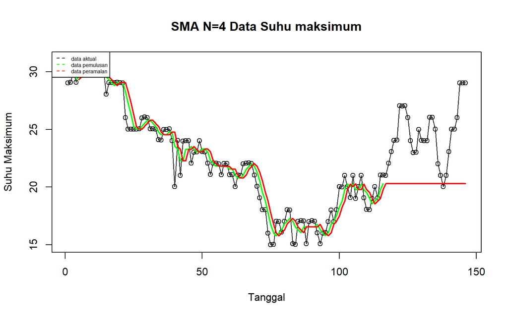

```r
ts.plot(data.ts, xlab="Tanggal", ylab="Suhu Maksimum", main= "SMA N=4 Data Suhu maksimum")
points(data.ts)
lines(data.gab[,2],col="green",lwd=2)
lines(data.gab[,3],col="red",lwd=2)
legend("topleft",c("data aktual","data pemulusan","data peramalan"), lty=8, col=c("black","green","red"), cex=0.5)
```

Selanjutnya perhitungan akurasi dilakukan dengan ukuran akurasi *Sum Squares Error* (SSE), *Mean Square Error* (MSE) dan *Mean Absolute Percentage Error* (MAPE). Perhitungan akurasi dilakukan baik pada data latih maupun pada data uji.

```r
#Menghitung nilai keakuratan data latih
error_train.sma = train.ts-data.ramal[1:length(train.ts)]

SSE_train.sma = sum(error_train.sma[5:length(train.ts)]^2)
MSE_train.sma = mean(error_train.sma[5:length(train.ts)]^2)
MAPE_train.sma = mean(abs((error_train.sma[5:length(train.ts)]/train.ts[5:length(train.ts)])*100))

akurasi_train.sma <- matrix(c(SSE_train.sma, MSE_train.sma, MAPE_train.sma))
row.names(akurasi_train.sma)<- c("SSE", "MSE", "MAPE")
colnames(akurasi_train.sma) <- c("Akurasi m = 4")
akurasi_train.sma
```

```
##      Akurasi m = 4
## SSE     190.844069
## MSE       1.703965
## MAPE      4.944315
```

Dalam hal ini nilai MAPE data latih pada metode pemulusan SMA sekitar 4,9%, nilai ini dapat dikategorikan sebagai nilai akurasi yang sangat baik. Selanjutnya dilakukan perhitungan nilai MAPE data uji pada metode pemulusan SMA.

```r
length(train.ts)
```

```
## [1] 116
```

```r
length(test.ts)
```

```
## [1] 30
```

```r
nrow(data.gab)
```

```
## [1] 146
```

```r
#Menghitung nilai keakuratan data uji
error_test.sma = test.ts-data.gab[117:146,3]

SSE_test.sma = sum(error_test.sma^2)
MSE_test.sma = mean(error_test.sma^2)
MAPE_test.sma = mean(abs((error_test.sma/test.ts*100)))

akurasi_test.sma <- matrix(c(SSE_test.sma, MSE_test.sma, MAPE_test.sma))
row.names(akurasi_test.sma)<- c("SSE", "MSE", "MAPE")
colnames(akurasi_test.sma) <- c("Akurasi m = 4")
akurasi_test.sma
```

```
##      Akurasi m = 4
## SSE      706.24120
## MSE       23.54137
## MAPE      16.54556
```

Perhitungan akurasi menggunakan data uji menghasilkan nilai MAPE sebesar 16.54%, berdasaran kriteria MAPE, nilai tersebut berada pada rentang 10%-20%, sehingga metode peramalan dapat dikategorikan memiliki akurasi yang baik

# Double Moving Average (DMA)

```r
dma <- SMA(data.sma, n=4)
At <- 2*data.sma - dma
Bt <- 2/(4-1)*(data.sma - dma)
data.dma <- At+Bt
data.ramal2 <- c(NA, data.dma)

t = 1:30
f = c()

for (i in t) {
  f[i] = At[length(At)] + Bt[length(Bt)]*(i)
}

data.gab2 <- cbind(aktual = c(data.ts),
                   pemulusan1 = c(data.sma, rep(NA,30)),
                   pemulusan2 = c(dma, rep(NA,30)),
                   At = c(At, rep(NA,30)),
                   Bt = c(Bt, rep(NA,30)),
                   ramalan = c(data.ramal2, f[-1]))
data.gab2
```

```
##        aktual pemulusan1 pemulusan2       At           Bt  ramalan
##   [1,]  29.02         NA         NA       NA           NA       NA
##   [2,]  29.07         NA         NA       NA           NA       NA
##   [3,]  30.03         NA         NA       NA           NA       NA
##   [4,]  29.09    29.3025         NA       NA           NA       NA
##   [5,]  30.07    29.5650         NA       NA           NA       NA
##   [6,]  30.09    29.8200         NA       NA           NA       NA
##   [7,]  30.07    29.8300   29.62937 30.03062  0.133750000       NA
##   [8,]  30.04    30.0675   29.82062 30.31437  0.164583333 30.16437
##   [9,]  30.00    30.0500   29.94187 30.15812  0.072083333 30.47896
##  [10,]  31.03    30.2850   30.05812 30.51187  0.151250000 30.23021
##  [11,]  31.07    30.5350   30.23437 30.83562  0.200416667 30.66312
##  [12,]  30.09    30.5475   30.35437 30.74063  0.128750000 31.03604
##  [13,]  30.04    30.5575   30.48125 30.63375  0.050833333 30.86938
##  [14,]  30.04    30.3100   30.48750 30.13250 -0.118333333 30.68458
```

[output cut: 132 more lines]

Hasil pemulusan menggunakan metode DMA divisualisasikan sebagai berikut

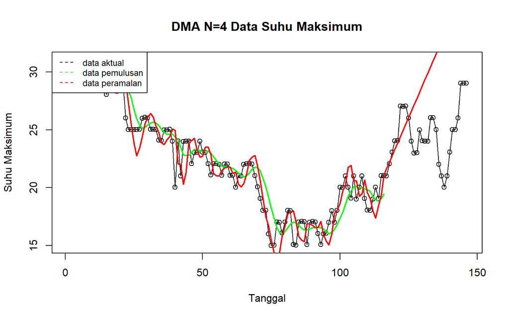

```r
ts.plot(data.ts, xlab="Tanggal", ylab="Suhu Maksimum", main= "DMA N=4 Data Suhu Maksimum")
points(data.ts)
lines(data.gab2[,3],col="green",lwd=2)
lines(data.gab2[,6],col="red",lwd=2)
legend("topleft",c("data aktual","data pemulusan","data peramalan"), lty=8, col=c("black","green","red"), cex=0.8)
```

Selanjutnya perhitungan akurasi dilakukan baik pada data latih maupun data uji. Perhitungan akurasi dilakukan dengan ukuran akurasi SSE, MSE dan MAPE.

```r
#Menghitung nilai keakuratan data latih
error_train.dma = train.ts-data.ramal2[1:length(train.ts)]

SSE_train.dma = sum(error_train.dma[8:length(train.ts)]^2)
MSE_train.dma = mean(error_train.dma[8:length(train.ts)]^2)
MAPE_train.dma = mean(abs((error_train.dma[8:length(train.ts)]/train.ts[8:length(train.ts)])*100))

akurasi_train.dma <- matrix(c(SSE_train.dma, MSE_train.dma, MAPE_train.dma))
row.names(akurasi_train.dma)<- c("SSE", "MSE", "MAPE")
colnames(akurasi_train.dma) <- c("Akurasi m = 4")
akurasi_train.dma
```

```
##      Akurasi m = 4
## SSE     219.025115
## MSE       2.009405
## MAPE      5.406314
```

Perhitungan akurasi pada data latih menggunakan nilai MAPE menghasilkan nilai MAPE yang kurang dari 10% sehingga dikategorikan sangat baik. Selanjutnya, perhitungan nilai akurasi dilakukan pada data uji.

```r
#Menghitung nilai keakuratan data uji
error_test.dma = test.ts-data.gab2[117:146,6]
SSE_test.dma = sum(error_test.dma^2)
MSE_test.dma = mean(error_test.dma^2)
MAPE_test.dma = mean(abs((error_test.dma/test.ts*100)))

akurasi_test.dma <- matrix(c(SSE_test.dma, MSE_test.dma, MAPE_test.dma))
row.names(akurasi_test.dma)<- c("SSE", "MSE", "MAPE")
colnames(akurasi_test.dma) <- c("Akurasi m = 4")
akurasi_test.dma
```

```
##      Akurasi m = 4
## SSE     1439.93176
## MSE       47.99773
## MAPE      23.37593
```

Pada data latih dan uji, kedduanya lebih baik menggunakan metode SMA dibandingkan dnegan metode DMA

# Single Exponential Smoothing & Double Exponential Smoothing

## Pembagian Data

Pembagian data latih dan data uji dilakukan dengan perbandingan 80% data latih dan 20% data uji.

```r
# jumlah baris data
n <- nrow(data)

# hitung batas 80%
n_train <- floor(0.8 * n)

# bagi data
training <- data[1:n_train, ]
testing  <- data[(n_train+1):n, ]

# ubah ke time series
train.ts <- ts(training$SUHU_MAX)
test.ts  <- ts(testing$SUHU_MAX)
```

## Eksplorasi

Eksplorasi dilakukan dengan membuat plot data deret waktu untuk keseluruhan data, data latih, dan data uji.

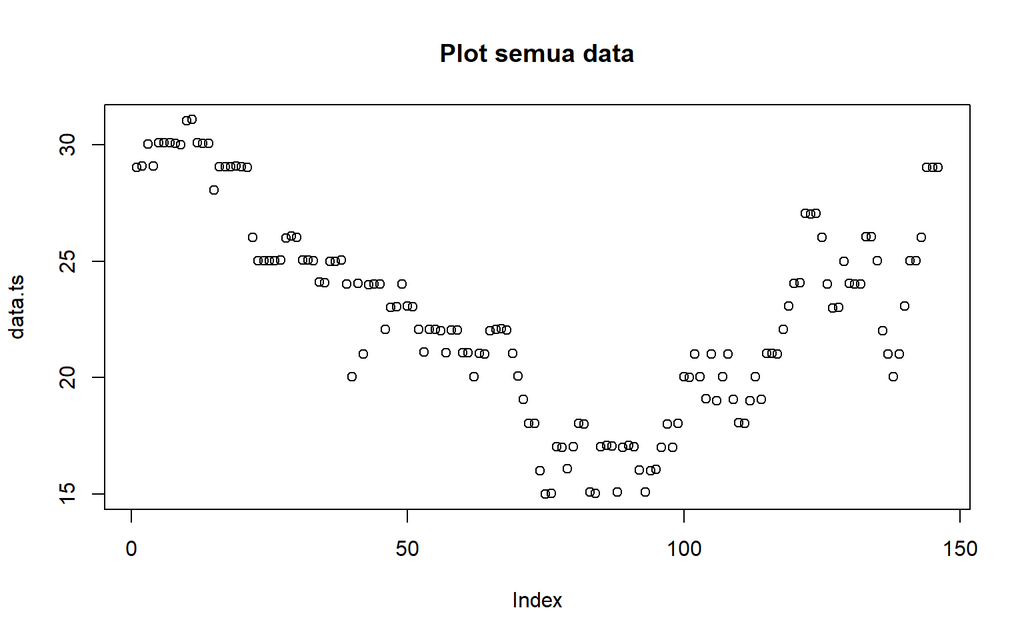

```r
plot(data.ts, col="black",main="Plot semua data")
points(data.ts)
```

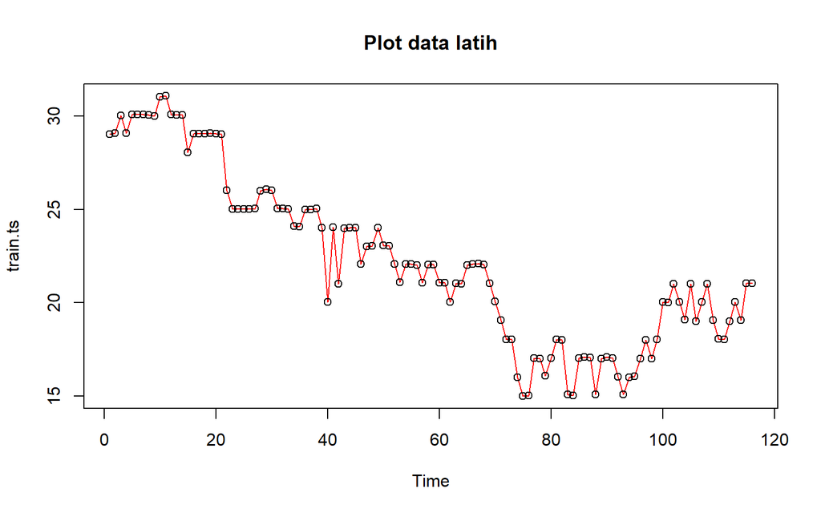

```r
plot(train.ts, col="red",main="Plot data latih")
points(train.ts)
```

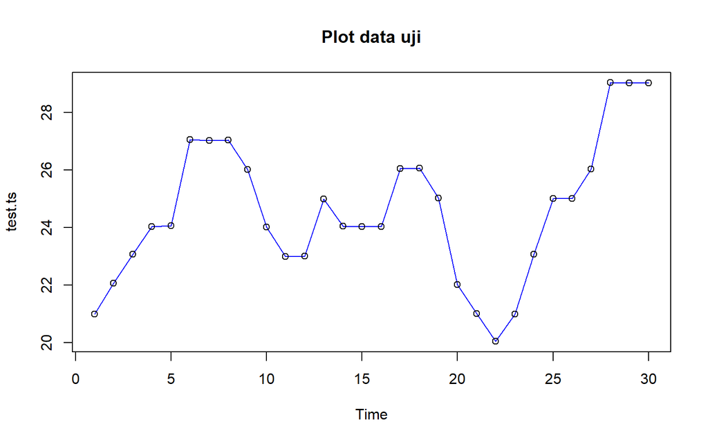

```r
plot(test.ts, col="blue",main="Plot data uji")
points(test.ts)
```

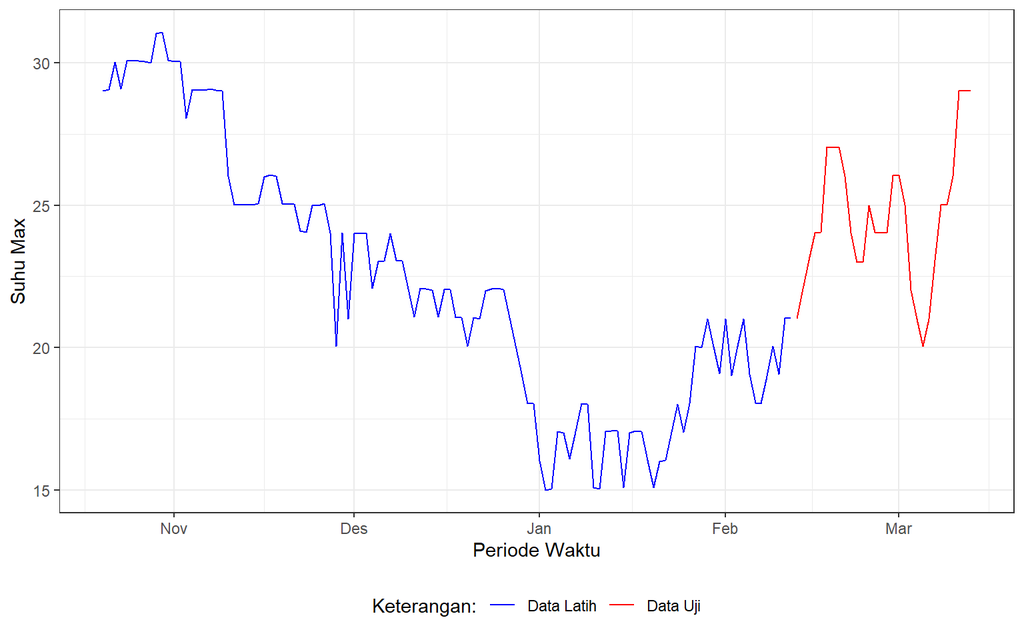

```r
library(ggplot2)
ggplot() +
  geom_line(data = training, aes(x = TANGGAL, y = SUHU_MAX, col = "Data Latih")) +
  geom_line(data = testing, aes(x = TANGGAL, y = SUHU_MAX, col = "Data Uji")) +
  labs(x = "Periode Waktu", y = "Suhu Max", color = "Legend") +
  scale_colour_manual(name="Keterangan:", breaks = c("Data Latih", "Data Uji"),
                      values = c("blue", "red")) +
  theme_bw() + theme(legend.position = "bottom",
                     plot.caption = element_text(hjust=0.5, size=12))
```

# Single Exponential Smoothing

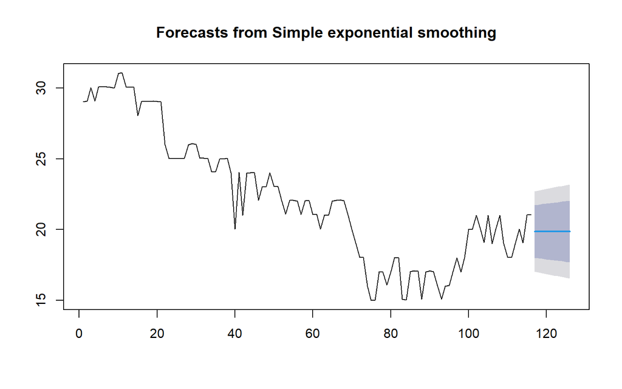

```r
#Cara 1 (fungsi ses)
library(forecast)
ses.1 <- ses(train.ts, h = 10, alpha = 0.2)
plot(ses.1)
```

```r
ses.1
```

```
##     Point Forecast    Lo 80    Hi 80    Lo 95    Hi 95
## 117       19.87067 18.01336 21.72798 17.03016 22.71118
## 118       19.87067 17.97658 21.76476 16.97391 22.76743
## 119       19.87067 17.94050 21.80084 16.91872 22.82261
## 120       19.87067 17.90508 21.83626 16.86456 22.87678
## 121       19.87067 17.87029 21.87105 16.81135 22.92999
## 122       19.87067 17.83609 21.90525 16.75905 22.98229
## 123       19.87067 17.80246 21.93888 16.70761 23.03372
## 124       19.87067 17.76936 21.97197 16.65700 23.08434
## 125       19.87067 17.73678 22.00455 16.60717 23.13416
## 126       19.87067 17.70469 22.03664 16.55809 23.18324
```

Untuk mendapatkan gambar hasil pemulusan pada data latih dengan fungsi ses() , perlu digunakan fungsi autoplot() dan autolayer() dari library packages ggplot2

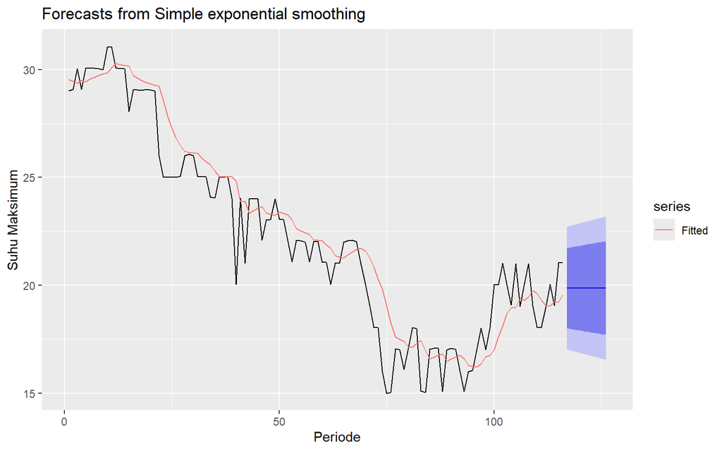

```r
autoplot(ses.1) +
  autolayer(fitted(ses.1), series="Fitted") +
  ylab("Suhu Maksimum") + xlab("Periode")
```

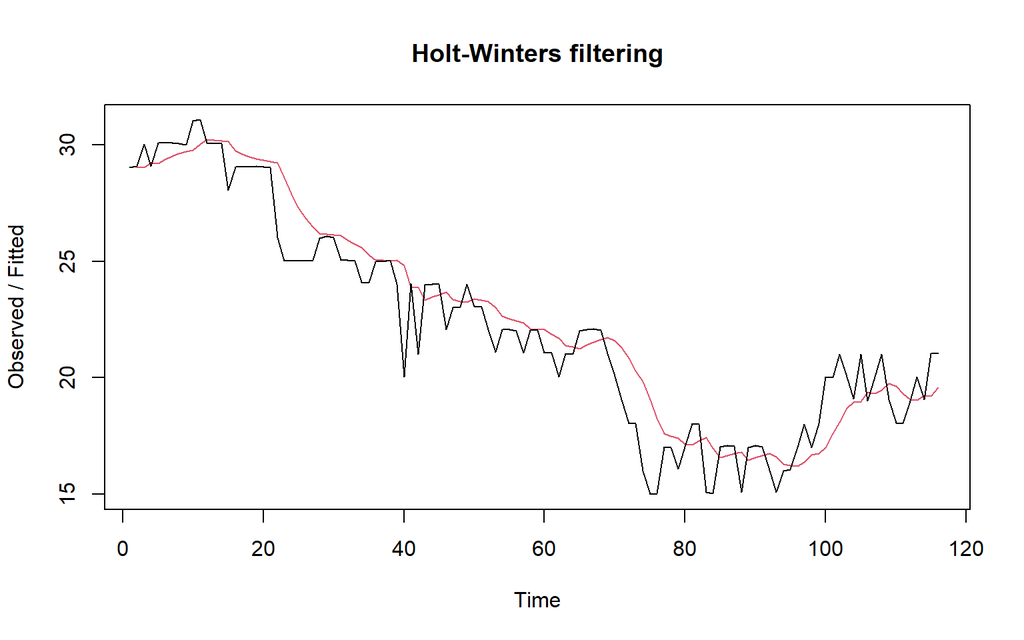

```r
#Cara 2 (fungsi Holtwinter)
ses1<- HoltWinters(train.ts, gamma = FALSE, beta = FALSE, alpha = 0.2)
plot(ses1)
```

```r
#ramalan
ramalan1<- forecast(ses1, h=30)
ramalan1
```

```
##     Point Forecast    Lo 80    Hi 80    Lo 95    Hi 95
## 117       19.87067 18.08218 21.65916 17.13541 22.60593
## 118       19.87067 18.04676 21.69458 17.08124 22.66009
## 119       19.87067 18.01202 21.72932 17.02810 22.71323
## 120       19.87067 17.97791 21.76343 16.97594 22.76539
## 121       19.87067 17.94441 21.79693 16.92470 22.81663
## 122       19.87067 17.91148 21.82986 16.87434 22.86699
## 123       19.87067 17.87909 21.86224 16.82481 22.91652
## 124       19.87067 17.84722 21.89411 16.77608 22.96526
## 125       19.87067 17.81585 21.92549 16.72810 23.01324
## 126       19.87067 17.78495 21.95639 16.68084 23.06050
## 127       19.87067 17.75450 21.98684 16.63427 23.10707
## 128       19.87067 17.72448 22.01685 16.58836 23.15298
## 129       19.87067 17.69488 22.04646 16.54308 23.19825
## 130       19.87067 17.66567 22.07567 16.49842 23.24292
```

[output cut: 16 more lines]

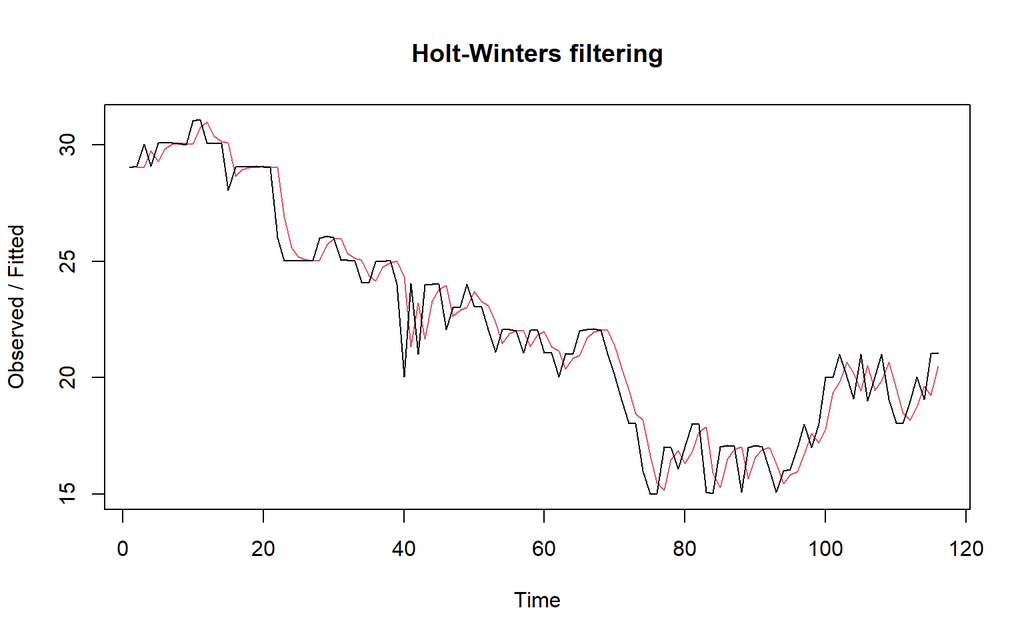

```r
ses2<- HoltWinters(train.ts, gamma = FALSE, beta = FALSE, alpha = 0.7)
plot(ses2)
```

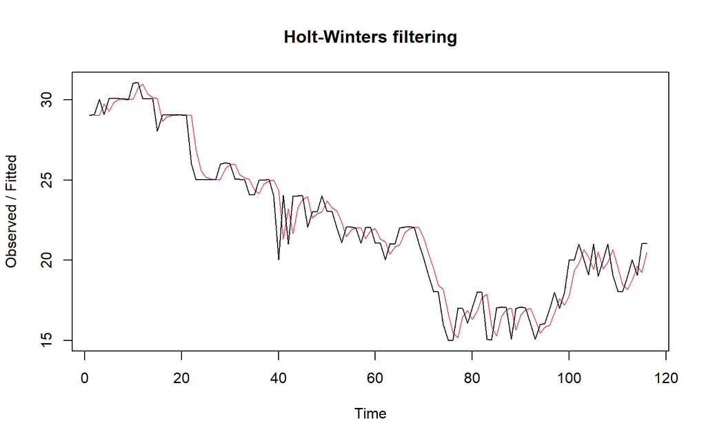

```r
ses2<- HoltWinters(train.ts, gamma = FALSE, beta = FALSE, alpha = 0.7)
plot(ses2)
```

```r
#ramalan
ramalan2<- forecast(ses2, h=30)
ramalan2
```

```
##     Point Forecast    Lo 80    Hi 80    Lo 95    Hi 95
## 117       20.88546 19.43154 22.33937 18.66188 23.10903
## 118       20.88546 19.11073 22.66019 18.17124 23.59967
## 119       20.88546 18.83962 22.93130 17.75661 24.01430
## 120       20.88546 18.60045 23.17046 17.39084 24.38008
## 121       20.88546 18.38404 23.38687 17.05988 24.71104
## 122       20.88546 18.18493 23.58599 16.75535 25.01556
## 123       20.88546 17.99952 23.77140 16.47179 25.29912
## 124       20.88546 17.82532 23.94560 16.20538 25.56554
## 125       20.88546 17.66051 24.11040 15.95333 25.81758
## 126       20.88546 17.50373 24.26718 15.71356 26.05735
## 127       20.88546 17.35391 24.41701 15.48442 26.28650
## 128       20.88546 17.21018 24.56073 15.26461 26.50630
## 129       20.88546 17.07187 24.69904 15.05308 26.71783
## 130       20.88546 16.93840 24.83251 14.84896 26.92195
```

[output cut: 16 more lines]

Nilai parameter $\alpha$ dari kedua fungsi dapat dioptimalkan menyesuaikan dari *error*-nya paling minimumnya. Caranya adalah dengan membuat parameter $\alpha =$ `NULL` .

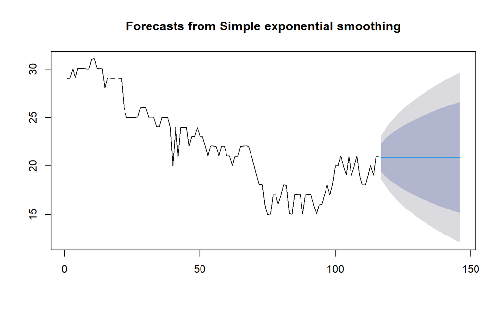

```r
ses.opt <- ses(train.ts, h = 30, alpha = NULL)
plot(ses.opt)
```

```r
ses.opt
```

```
##     Point Forecast    Lo 80    Hi 80    Lo 95    Hi 95
## 117       20.89257 19.43292 22.35222 18.66022 23.12491
## 118       20.89257 19.10521 22.67992 18.15904 23.62609
## 119       20.89257 18.82890 22.95623 17.73647 24.04867
## 120       20.89257 18.58545 23.19968 17.36414 24.42099
## 121       20.89257 18.36535 23.41979 17.02752 24.75761
## 122       20.89257 18.16293 23.62220 16.71795 25.06718
## 123       20.89257 17.97452 23.81061 16.42981 25.35533
## 124       20.89257 17.79757 23.98757 16.15917 25.62596
## 125       20.89257 17.63019 24.15494 15.90319 25.88194
## 126       20.89257 17.47099 24.31414 15.65972 26.12541
## 127       20.89257 17.31888 24.46625 15.42709 26.35805
## 128       20.89257 17.17298 24.61215 15.20396 26.58118
## 129       20.89257 17.03260 24.75253 14.98925 26.79588
## 130       20.89257 16.89714 24.88799 14.78209 27.00304
```

[output cut: 16 more lines]

```r
#Lamda Optimum Holt Winter
HWopt<- HoltWinters(train.ts, gamma = FALSE, beta = FALSE,alpha = NULL)
HWopt
```

```
## Holt-Winters exponential smoothing without trend and without seasonal component.
##
## Call:
## HoltWinters(x = train.ts, alpha = NULL, beta = FALSE, gamma = FALSE)
##
## Smoothing parameters:
##  alpha: 0.7070476
##  beta : FALSE
##  gamma: FALSE
##
## Coefficients:
##       [,1]
## a 20.89293
```

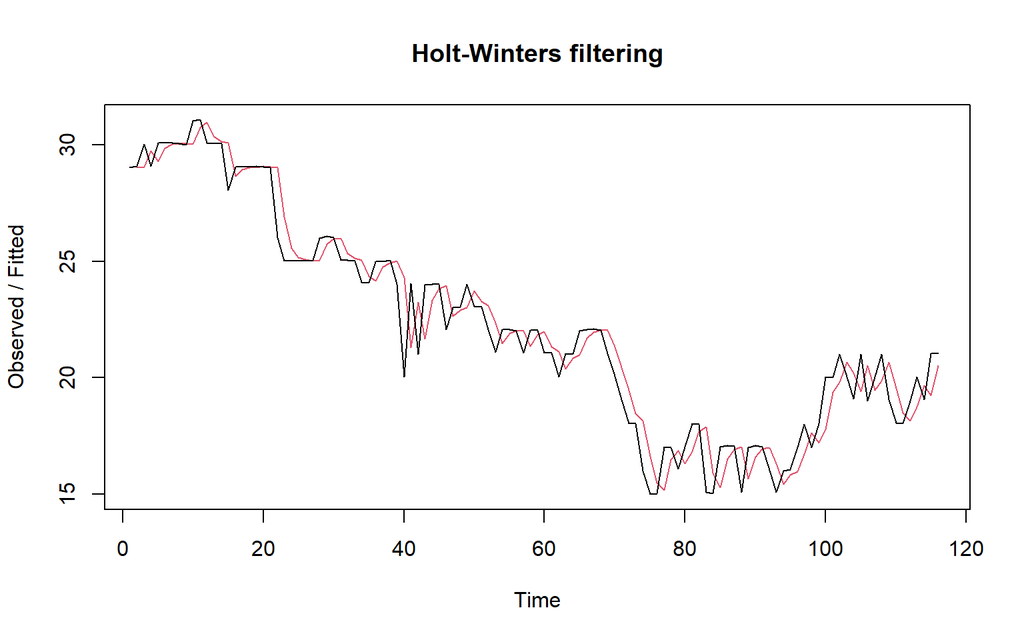

```r
plot(HWopt)
```

```r
#ramalan
ramalanopt <- forecast(HWopt, h=30)
ramalanopt
```

```
##     Point Forecast    Lo 80    Hi 80    Lo 95    Hi 95
## 117       20.89293 19.43893 22.34694 18.66922 23.11664
## 118       20.89293 19.11220 22.67367 18.16953 23.61633
## 119       20.89293 18.83674 22.94912 17.74826 24.03760
## 120       20.89293 18.59406 23.19180 17.37712 24.40875
## 121       20.89293 18.37466 23.41120 17.04157 24.74429
## 122       20.89293 18.17290 23.61296 16.73300 25.05286
## 123       20.89293 17.98510 23.80076 16.44579 25.34007
## 124       20.89293 17.80872 23.97714 16.17604 25.60982
## 125       20.89293 17.64189 24.14397 15.92090 25.86496
## 126       20.89293 17.48322 24.30264 15.67823 26.10763
## 127       20.89293 17.33161 24.45425 15.44636 26.33950
## 128       20.89293 17.18619 24.59967 15.22397 26.56189
## 129       20.89293 17.04627 24.73959 15.00997 26.77589
## 130       20.89293 16.91126 24.87460 14.80350 26.98236
```

[output cut: 16 more lines]

Setelah dilakukan peramalan, akan dilakukan perhitungan keakuratan hasil peramalan. Perhitungan akurasi ini dilakukan baik pada data latih dan data uji.

### Akurasi Data Latih

Perhitungan akurasi data dapat dilakukan dnegan cara langsung maupun manua;;. Secara langsung, nilai akurasi dapat diambil dari objek yang tersimpann pada hasil SES, yaitu *sum od squared errors* (SSE). Nilai akurasi lain dapat dihitung pula dari nilai SSE tersebut.

```r
#Keakuratan Metode
#Pada data training

# SES dengan alpha = 0.2
SSE1<-ses1$SSE
MSE1<-ses1$SSE/length(train.ts)
RMSE1<-sqrt(MSE1)

akurasi1 <- matrix(c(SSE1,MSE1,RMSE1))
row.names(akurasi1)<- c("SSE", "MSE", "RMSE")
colnames(akurasi1) <- c("Akurasi lamda=0.2")
akurasi1
```

```
##      Akurasi lamda=0.2
## SSE         240.224602
## MSE           2.070902
## RMSE          1.439063
```

```r
# SES dengan alpha = 0.7
SSE2<-ses2$SSE
MSE2<-ses2$SSE/length(train.ts)
RMSE2<-sqrt(MSE2)

akurasi2 <- matrix(c(SSE2,MSE2,RMSE2))
row.names(akurasi2)<- c("SSE", "MSE", "RMSE")
colnames(akurasi2) <- c("Akurasi lamda=0.7")
akurasi2
```

```
##      Akurasi lamda=0.7
## SSE         147.901724
## MSE           1.275015
## RMSE          1.129166
```

```r
#Cara Manual
# Alpha = 0.2
sisaan1<-ramalan1$residuals
head(sisaan1)
```

```
## Time Series:
## Start = 1
## End = 6
## Frequency = 1
## [1]      NA  0.0500  1.0000 -0.1400  0.8680  0.7144
```

```r
SSE.1=sum(sisaan1[2:length(train.ts)]^2)
SSE.1
```

```
## [1] 240.2246
```

```r
MSE.1 = SSE.1/length(train.ts)
MSE.1
```

```
## [1] 2.070902
```

```r
MAPE.1 = sum(abs(sisaan1[2:length(train.ts)]/train.ts[2:length(train.ts)])*
               100)/length(train.ts)
MAPE.1
```

```
## [1] 5.172483
```

```r
akurasi.1 <- matrix(c(SSE.1,MSE.1,MAPE.1))
row.names(akurasi.1)<- c("SSE", "MSE", "MAPE")
colnames(akurasi.1) <- c("Akurasi lamda=0.2")
akurasi.1
```

```
##      Akurasi lamda=0.2
## SSE         240.224602
## MSE           2.070902
## MAPE          5.172483
```

```r
# Alpha = 0.7
sisaan2<-ramalan2$residuals
head(sisaan2)
```

```
## Time Series:
## Start = 1
## End = 6
## Frequency = 1
## [1]        NA  0.050000  0.975000 -0.647500  0.785750  0.255725
```

```r
SSE.2=sum(sisaan2[2:length(train.ts)]^2)
SSE.2
```

```
## [1] 147.9017
```

```r
MSE.2 = SSE.2/length(train.ts)
MSE.2
```

```
## [1] 1.275015
```

```r
MAPE.2 = sum(abs(sisaan2[2:length(train.ts)]/train.ts[2:length(train.ts)])*
               100)/length(train.ts)
MAPE.2
```

```
## [1] 4.175245
```

```r
akurasi.2 <- matrix(c(SSE.2,MSE.2,MAPE.2))
row.names(akurasi.2)<- c("SSE", "MSE", "MAPE")
colnames(akurasi.2) <- c("Akurasi lamda=0.7")
akurasi.2
```

```
##      Akurasi lamda=0.7
## SSE         147.901724
## MSE           1.275015
## MAPE          4.175245
```

Berdasarkan nilai SSE, MSE, RMSE, dan MAPE di antara kedua parameter, nilai parameter $\lambda=0,7$ menghasilkan akurasi yang lebih baik dibanding $\lambda=0,2$ . Hal ini dilihat dari nilai masing-masing ukuran akurasi yang lebih kecil. Berdasarkan nilai MAPE-nya, hasil ini dapat dikategorikan sebagai peramalan sangat baik.

## Akurasi Data Uji

Akurasi data uji dapat dihitung dengan cara yang hampir sama dengan perhitungan akurasi data latih

```r
#jumlah data uji
n_test <- nrow(testing)

# error (ramalan - aktual), samakan panjang dan tipe numeric
e1   <- as.numeric(ramalan1$mean)[1:n_test] - as.numeric(testing$SUHU_MAX)
e2   <- as.numeric(ramalan2$mean)[1:n_test] - as.numeric(testing$SUHU_MAX)
eopt <- as.numeric(ramalanopt$mean)[1:n_test] - as.numeric(testing$SUHU_MAX)

# SSE / MSE / RMSE untuk masing-masing model (abaikan NA)
SSEtesting1  <- sum(e1^2,  na.rm = TRUE)
MSEtesting1  <- mean(e1^2, na.rm = TRUE)
RMSEtesting1 <- sqrt(MSEtesting1)

SSEtesting2  <- sum(e2^2,  na.rm = TRUE)
MSEtesting2  <- mean(e2^2, na.rm = TRUE)
RMSEtesting2 <- sqrt(MSEtesting2)

SSEtestingopt  <- sum(eopt^2,  na.rm = TRUE)
MSEtestingopt  <- mean(eopt^2, na.rm = TRUE)
RMSEtestingopt <- sqrt(MSEtestingopt)

# Tabel ringkas
akurasitesting_SSE <- matrix(c(SSEtesting1, SSEtesting2, SSEtestingopt),
                             nrow = 3,
                             dimnames = list(c("SSE1","SSE2","SSEopt"), "Nilai"))
akurasitesting_MSE <- matrix(c(MSEtesting1, MSEtesting2, MSEtestingopt),
                             nrow = 3,
                             dimnames = list(c("MSE1","MSE2","MSEopt"), "Nilai"))
akurasitesting_RMSE <- matrix(c(RMSEtesting1, RMSEtesting2, RMSEtestingopt),
                              nrow = 3,
                              dimnames = list(c("RMSE1","RMSE2","RMSEopt"), "Nilai"))

akurasitesting_SSE
```

```
##           Nilai
## SSE1   820.7355
## SSE2   567.9351
## SSEopt 566.3024
```

```r
akurasitesting_MSE
```

```
##           Nilai
## MSE1   27.35785
## MSE2   18.93117
## MSEopt 18.87675
```

```r
akurasitesting_RMSE
```

```
##            Nilai
## RMSE1   5.230473
## RMSE2   4.350997
## RMSEopt 4.344738
```

Selain dengan cara di atas, perhitungan nilai akurasi dapat menggunakan fungsi `accuracy()` dari *package* `forecast`.

```r
accuracy(ramalan1, testing$SUHU_MAX)
```

```
##                     ME     RMSE      MAE       MPE      MAPE     MASE      ACF1
## Training set -0.397797 1.445306 1.056079 -2.110526  5.217461 1.318235 0.5684167
## Test set      4.659332 5.230473 4.659332 18.229204 18.229204 5.815947        NA
```

```r
accuracy(ramalan2, testing$SUHU_MAX)
```

```
##                      ME     RMSE       MAE        MPE      MAPE     MASE
## Training set -0.1010502 1.134064 0.8496429 -0.6174036  4.211552 1.060555
## Test set      3.6445435 4.350997 3.7002406 14.0531960 14.330987 4.618774
##                    ACF1
## Training set 0.00144398
## Test set             NA
```

```r
accuracy(ramalanopt, testing$SUHU_MAX)
```

```
##                       ME     RMSE      MAE        MPE      MAPE     MASE
## Training set -0.09995108 1.134035 0.848417 -0.6117127  4.205012 1.059025
## Test set      3.63706951 4.344738 3.693265 14.0224394 14.302716 4.610067
##                      ACF1
## Training set -0.005385596
## Test set               NA
```

Hasil menunjukkan bahwa metode SES dengan parameter optimal merupakan metode terbaik karena menghasilkan nilai error atau ukuran akurasi yang paling kecil dibandingkan metode lainnya.

# Double Exponential Smoothing (DES)

## Forecasting dengan Fungsi Holtwintes

Pemulusan dengan metode DES kali ini akan menggunakan fungsi `HoltWinters()`. Jika sebelumnya nilai argumen `beta` dibuat `FALSE`, kali ini argumen tersebut akan diinisiasi bersama dengan nilai `alpha`.

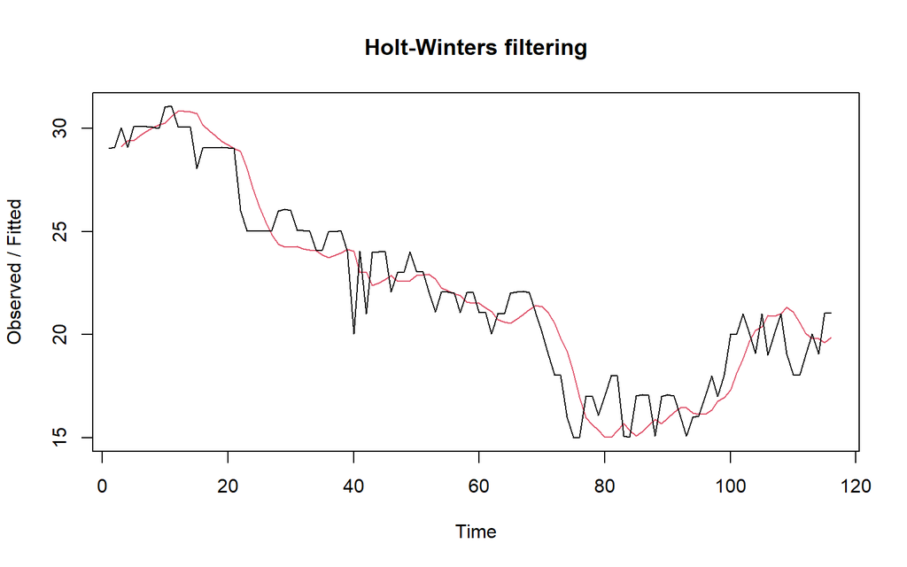

```r
#Lamda=0.2 dan gamma=0.2
des.1 <- HoltWinters(train.ts, gamma = FALSE, beta = 0.2, alpha = 0.2)
plot(des.1)
```

```r
#ramalan
ramalandes1 <- forecast(des.1, h=30)
ramalandes1
```

```
##     Point Forecast    Lo 80    Hi 80     Lo 95    Hi 95
## 117       20.14646 18.32978 21.96315 17.368085 22.92484
## 118       20.18245 18.31418 22.05072 17.325172 23.03973
## 119       20.21843 18.28215 22.15472 17.257144 23.17972
## 120       20.25442 18.23275 22.27609 17.162541 23.34629
## 121       20.29040 18.16558 22.41522 17.040766 23.54004
## 122       20.32639 18.08074 22.57203 16.891966 23.76080
## 123       20.36237 17.97870 22.74604 16.716864 24.00787
## 124       20.39835 17.86019 22.93652 16.516568 24.28014
## 125       20.43434 17.72608 23.14260 16.292408 24.57627
## 126       20.47032 17.57728 23.36336 16.045801 24.89484
## 127       20.50631 17.41474 23.59787 15.778160 25.23445
## 128       20.54229 17.23932 23.84526 15.490832 25.59375
## 129       20.57827 17.05185 24.10470 15.185068 25.97148
## 130       20.61426 16.85306 24.37545 14.862006 26.36651
```

[output cut: 16 more lines]

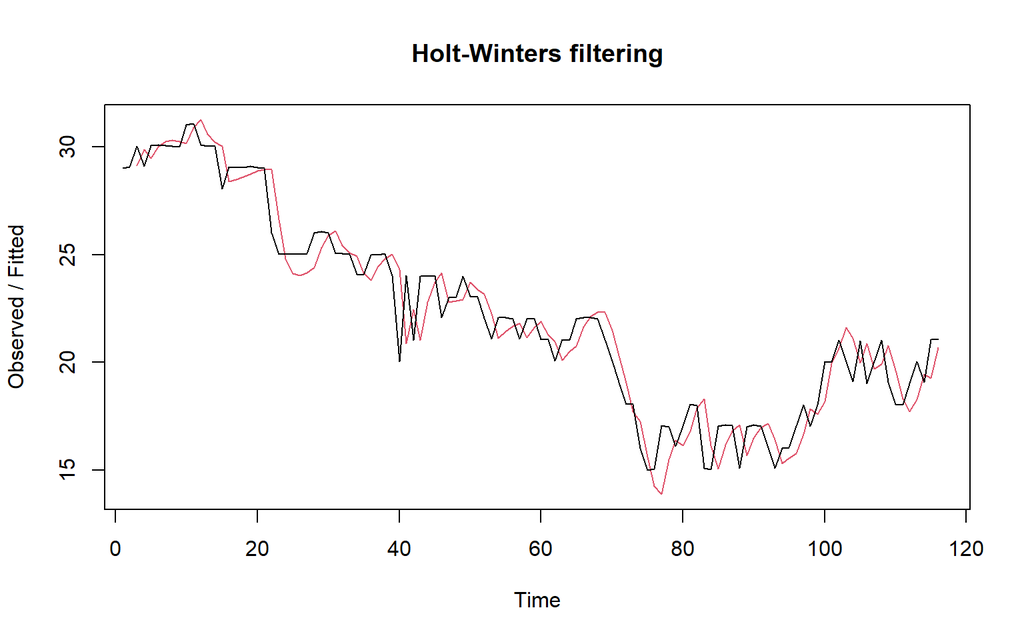

```r
#Lambda=0.6 dan gamma = 0.3
des.2 <- HoltWinters(train.ts, gamma = FALSE, beta = 0.3, alpha = 0.6)
plot(des.2)
```

```r
#ramalan
ramalandes2 <- forecast(des.2, h=30)
ramalandes2
```

```
##     Point Forecast     Lo 80    Hi 80       Lo 95    Hi 95
## 117       21.33582 19.752746 22.91889  18.9147183 23.75692
## 118       21.76400 19.756303 23.77169  18.6934943 24.83450
## 119       22.19218 19.674148 24.71021  18.3411842 26.04317
## 120       22.62036 19.522388 25.71833  17.8824216 27.35829
## 121       23.04854 19.311685 26.78539  17.3335140 28.76356
## 122       23.47672 19.049210 27.90423  16.7054283 30.24801
## 123       23.90490 18.740008 29.06979  16.0058806 31.80392
## 124       24.33308 18.387808 30.27835  15.2405715 33.42559
## 125       24.76126 17.995485 31.52703  14.4139010 35.10862
## 126       25.18944 17.565344 32.81353  13.5293914 36.84949
## 127       25.61762 17.099283 34.13596  12.5899483 38.64529
## 128       26.04580 16.598908 35.49269  11.5980260 40.49357
## 129       26.47398 16.065602 36.88236  10.5557390 42.39222
## 130       26.90216 15.500573 38.30375   9.4649370 44.33938
```

[output cut: 16 more lines]

## Perbandingan plot data latih dan data uji

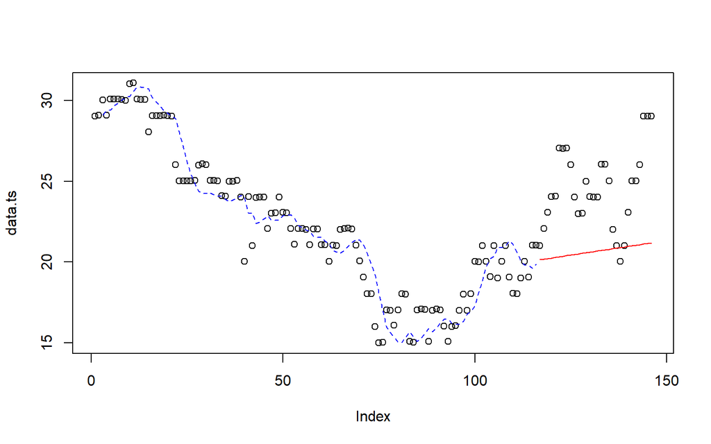

```r
plot(data.ts)
lines(des.1$fitted[,1], lty=2, col="blue")
lines(ramalandes1$mean, col="red")
```

Untuk mendapatkan nilai parameter optimum dari DES, argumen `alpha` dan `beta` dapat dibuat `NULL` seperti berikut

```r
#Lambda dan gamma optimum
des.opt <- HoltWinters(train.ts, gamma = FALSE)
des.opt
```

```
## Holt-Winters exponential smoothing with trend and without seasonal component.
##
## Call:
## HoltWinters(x = train.ts, gamma = FALSE)
##
## Smoothing parameters:
##  alpha: 0.7125274
##  beta : 0.00809858
##  gamma: FALSE
##
## Coefficients:
##           [,1]
## a 20.892953112
## b -0.007922611
```

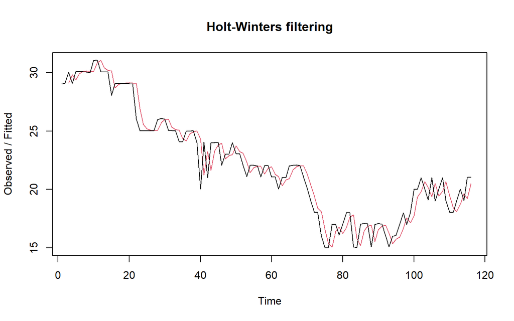

```r
plot(des.opt)
```

```r
#ramalan
ramalandesopt <- forecast(des.opt, h=30)
ramalandesopt
```

```
##     Point Forecast    Lo 80    Hi 80    Lo 95    Hi 95
## 117       20.88503 19.41569 22.35437 18.63786 23.13220
## 118       20.87711 19.06799 22.68622 18.11031 23.64391
## 119       20.86919 18.77043 22.96795 17.65941 24.07896
## 120       20.86126 18.50440 23.21813 17.25675 24.46577
## 121       20.85334 18.26045 23.44623 16.88786 24.81882
## 122       20.84542 18.03299 23.65784 16.54419 25.14665
## 123       20.83749 17.81840 23.85659 16.22019 25.45480
## 124       20.82957 17.61417 24.04498 15.91203 25.74711
## 125       20.82165 17.41848 24.22482 15.61695 26.02635
## 126       20.81373 17.22998 24.39748 15.33285 26.29460
## 127       20.80580 17.04760 24.56401 15.05813 26.55348
## 128       20.79788 16.87052 24.72525 14.79150 26.80427
## 129       20.78996 16.69805 24.88186 14.53193 27.04799
## 130       20.78204 16.52966 25.03442 14.27858 27.28549
```

[output cut: 16 more lines]

Selanjutnya akan dilakukan perhitungan akurasi pada l=data latih maupun data uji dengan ukuran akurasi SSE, MSE, dan MAPE